# Reproducing the 6 × 6 calibration experiment with spDBL

This reruns the data setup and plots in `vignettes/reproduce/calibrate_EP_sigma2R.R` using the installed spDBL package. It fits the emulator to the same 40 original simulator runs, assesses all ten held-out runs, generates the original synthetic-field experiment on 36 sites and 26 times, and calibrates **eta1, eta2, and alpha2**, with **alpha1 = alpha3 = 0**.

The full experiment uses **30,000 emulator draws** (`nsam <- 3 * 10^4`). This rendered report uses the **full profile** with **30,000 draws**. The quick profile has 300 draws. Each profile uses one calibration transition per draw and saves its results separately. Rendering this source directly defaults to quick; the command-line runner defaults to full.

The inference step uses the current package workflow: `emulator_learn()` → `calibration_prepare()` → `calibration_fit()` → `calibration_predict()`. The custom Metropolis/Gibbs updates in the development script are replaced by Stan, and GP means replace PDE evaluations during calibration. This is an approximate reproduction using the package method, not a bit-for-bit rerun of the old inference algorithm.

## Original data and settings

| Setting | Reproduction |
| --- | --- |
| CSV inputs | `data/calibration/pde_para.csv` and all 50 `pde_solution_*.csv` |
| Training / validation | Original rows 1–40 / 41–50 |
| Grid and time | 6 × 6; times 0–25 |
| Episode blocks | Two strips per block, 12 sites, three blocks per time |
| Emulator | Scalar $\sigma^2R$, AR2, 78 episodes, 24 × 12 coefficients |
| Kernel | Exponential, tuning 0.5, amplitude 1.1, nugget 0.0001 |
| Emulator prior | $n_0=27,D_0=36$, all-one coefficient mean, identity left covariance |
| Emulator draws | 30,000 smoothed-marginal coefficient sets |
| Field truth | Input 50: $(3,0.3,0,0.1,0)$; saved log(I + 1) trajectory |
| Synthetic discrepancy | $u_0=0$, $\tau_t^2\sim\mathrm{IG}(30,2)$, random-walk increments |
| Field covariance | Original full-grid kernel, diagonal 1.1001, without normalization |
| Calibration priors | $n_0=30,d_0=2,b=1,m_0=0,M_0=I$ |
| Estimated parameter bounds | eta1: $[2,4]$; eta2: $[0.2,0.4]$; alpha2: $[0,0.2]$ |
| Fixed parameters | alpha1 = alpha3 = 0 |
| Observation sites | All 36, using the original random permutation |
| Current calibration controls | One chain, one transition per draw, zero warmup |

`alpha1` and `alpha3` are zero in every original training input. They are fixed at zero by giving them equal lower and upper bounds. Stan samples only the three active parameters. Saved mechanistic-parameter arrays retain all five columns for compatibility, with the two fixed columns identically zero. This restriction replaces the five-free-parameter setup in the development script; the data, emulator draws, and remaining settings are preserved.

## End-to-end experiment

The helper builds both the training and held-out AR2 rows before sampling, following the original seed-1234 sequence. It checks the RNG state against an explicit replay of the original gamma and normal draw counts before generating the synthetic field with `gen_calibrate_data()`. GP mean prediction consumes no random numbers. The truth trajectory is read from saved input 50, so this reproduction calls no PDE solver.

As in the development script, synthetic-field generation follows coefficient sampling in the same RNG stream. The 30,000-draw full profile therefore generates a different synthetic field realization from the 300-draw quick profile, using the same saved truth trajectory, covariance, and generative model.

For the completed quick profile, an independent check also executed the original development sampler against the same package filtering results. It reproduced the generated `z`, `u`, `tau2`, and the observation-site permutation exactly; its check log is retained with the calibration outputs.

The former unit-diagonal restriction on `calibration_fit(U=...)` has been relaxed to accept a symmetric positive-definite covariance scale. This preserves the original ratio between discrepancy and observation variance:

$$u_t\mid u_{t-1},\tau_t^2\sim N(u_{t-1},\tau_t^2 U),\qquad
z_t\mid y_t,u_t,\tau_t^2\sim N(y_t+u_t,\tau_t^2 I).$$

```r
r <- if (isTRUE(params$render_only)) reproduction_cached_results(root, "calibration", profile) else
  run_calibration_reproduction(root, profile = profile)
r$manifest$settings
```

```
## $Nx
## [1] 6
##
## $Ny
## [1] 6
##
## $times
##  [1]  0  1  2  3  4  5  6  7  8  9 10 11 12 13 14 15 16 17 18 19 20 21 22 23 24
## [26] 25
##
## $train
##  [1]  1  2  3  4  5  6  7  8  9 10 11 12 13 14 15 16 17 18 19 20 21 22 23 24 25
## [26] 26 27 28 29 30 31 32 33 34 35 36 37 38 39 40
##
## $validation
##  [1] 41 42 43 44 45 46 47 48 49 50
##
## $window
## [1] 2
##
## $nsam
## [1] 30000
##
## $AR
## [1] 2
##
## $seed
## [1] 1234
##
## $gp_tune
## [1] 0.5
##
## $gp_sigma2
## [1] 1.1
##
## $gp_tau2
## [1] 1e-04
##
## $sampling
## [1] "marginal"
```

[output cut: 18 more lines]

```
##
## $calibration_seed
## [1] 12345678
##
## $n0
## [1] 30
##
## $d0
## [1] 2
##
## $discount
## [1] 1
##
## $discrepancy_covariance
## [1] "original unnormalised kernel"
```

The main API calls inside the helper are:

```r
# s$F and s$F_test are constructed in the original RNG order.
em <- spDBL::emulator_learn(
  d$input[1:40, ], d$train, 6, 6, F_ls_train = s$F,
  covariance = "sigma2R", episode_window = 2,
  nsam = n_emulator, sampling = "marginal", seed = NULL
)
cal <- spDBL::calibration_prepare(
  em, lower = c(2, 0.2, 0, 0, 0), upper = c(4, 0.4, 0, 0.2, 0)
)
fit <- spDBL::calibration_fit(
  cal, z = field$z[, field$locations], U = field$U,
  locations = field$locations, seed = 12345678,
  iter = 1, warmup = 0, chains = 1, draws_per_emulator = 1,
  n0 = 30, d0 = 2, discount = 1
)
prediction <- spDBL::calibration_predict(fit, seed = 12345679)
```

For a fixed emulator draw, the package combines an offline GP prediction of the AR2 rows with conditional GP residual interpolation. Schematically,

$$\mu_e(\eta)=\widehat F_e(\eta)\Theta_e+
J(\eta)^\top V^{-1}(Y_e-F_e\Theta_e),$$

$$\Sigma(\eta)=\sigma^2\left\{1.1001-J(\eta)^\top
V^{-1}J(\eta)\right\}R_{\rm field}.$$

The diagonal input nugget is not added to cross-covariances between independent simulator runs. The offline AR2 GP is used through its fitted mean; uncertainty in those fitted design rows is omitted. Stan integrates out emulator fields and discrepancy trajectories with the marginal likelihood, then the package recovers latent trajectories conditionally on the observations.

## Check the GP approximation on the same held-out inputs

```r
knitr::kable(r$validation, digits = 5,
  caption = "All 26 times and 36 sites, on the saved log(I + 1) scale.")
```

All 26 times and 36 sites, on the saved log(I + 1) scale.

| method | input_id | RMSE | MAE | max_abs_error |
| --- | --- | --- | --- | --- |
| Original saved-lag AR2 means | 41 | 0.03068 | 0.01288 | 0.32586 |
| Original saved-lag AR2 means | 42 | 0.02665 | 0.01007 | 0.29781 |
| Original saved-lag AR2 means | 43 | 0.02413 | 0.00969 | 0.30963 |
| Original saved-lag AR2 means | 44 | 0.06451 | 0.02105 | 0.87220 |
| Original saved-lag AR2 means | 45 | 0.12245 | 0.03689 | 1.80576 |
| Original saved-lag AR2 means | 46 | 0.05073 | 0.02410 | 0.47116 |
| Original saved-lag AR2 means | 47 | 0.05513 | 0.01539 | 0.84841 |
| Original saved-lag AR2 means | 48 | 0.02038 | 0.00835 | 0.27023 |
| Original saved-lag AR2 means | 49 | 0.11080 | 0.04037 | 0.92816 |
| Original saved-lag AR2 means | 50 | 0.00949 | 0.00371 | 0.12086 |
| PDE-free offline AR2 GP means | 41 | 0.34700 | 0.24086 | 1.76792 |
| PDE-free offline AR2 GP means | 42 | 0.06861 | 0.05000 | 0.54200 |
| PDE-free offline AR2 GP means | 43 | 0.11341 | 0.09621 | 0.41248 |
| PDE-free offline AR2 GP means | 44 | 0.44101 | 0.29309 | 2.50558 |
| PDE-free offline AR2 GP means | 45 | 0.33448 | 0.24402 | 1.91134 |
| PDE-free offline AR2 GP means | 46 | 0.52530 | 0.28316 | 2.71087 |
| PDE-free offline AR2 GP means | 47 | 0.12519 | 0.07699 | 0.87954 |
| PDE-free offline AR2 GP means | 48 | 0.09292 | 0.07742 | 0.25936 |
| PDE-free offline AR2 GP means | 49 | 0.61604 | 0.45098 | 2.07078 |
| PDE-free offline AR2 GP means | 50 | 0.02551 | 0.01656 | 0.14579 |

The saved-lag baseline uses the original held-out AR2 features. The offline method predicts those features from parameter inputs alone. These two checks separate ordinary emulator interpolation from the additional approximation needed for PDE-free calibration. The field truth run is held out from training.

## Three estimated parameter histograms

```r
knitr::kable(r$eta[r$eta$parameter %in% r$active_parameters, ], digits = 6,
  caption = paste("Descriptive quantiles across", format(n_emulator, big.mark = ","),
    "one-transition conditional runs."))
```

Descriptive quantiles across 30,000 one-transition conditional runs.

|  | parameter | true | lower | median | upper |
| --- | --- | --- | --- | --- | --- |
| 1 | eta1 | 3.0 | 2.903721 | 2.957080 | 3.061957 |
| 2 | eta2 | 0.3 | 0.283286 | 0.303720 | 0.328732 |
| 4 | alpha2 | 0.1 | 0.091084 | 0.102349 | 0.109020 |

```r
knitr::kable(data.frame(parameter = names(r$fixed_parameters),
  fixed_value = unname(r$fixed_parameters)), caption = "Parameters fixed during calibration.")
```

Parameters fixed during calibration.

| parameter | fixed_value |
| --- | --- |
| alpha1 | 0 |
| alpha3 | 0 |

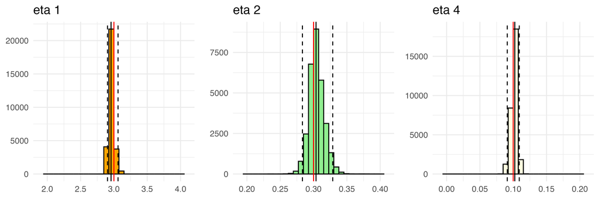

The histograms follow the original orange, light-green, and light-yellow fills for eta1, eta2, and eta4 (alpha2), with black outlines. Red marks the generating value; solid black marks the median and dashed black marks the 2.5% and 97.5% quantiles. The prior-range axis limits, minimal theme, font sizes, and 45 × 15 cm export at 300 dpi match the development script.

## Latent-field heat-map panel

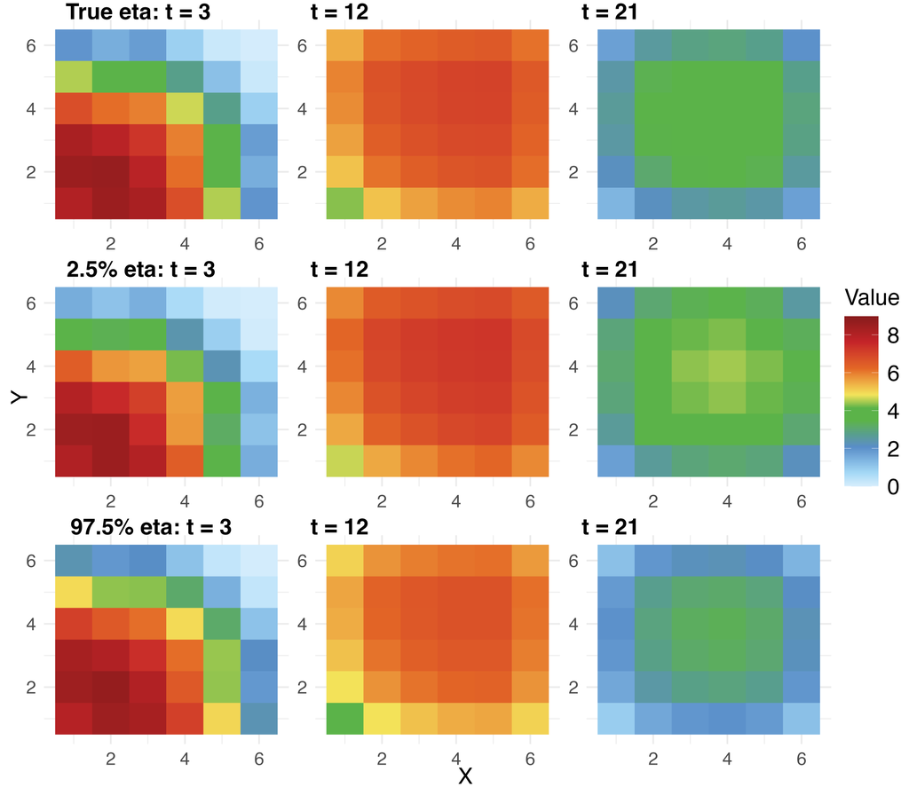

Original 3 × 3 layout at times 3, 12, and 21. Rows show the saved simulator truth, GP mean at the componentwise 2.5% parameter vector, and GP mean at the componentwise 97.5% vector.

This is `plot_heat_y_panel` from the original experiment, using GP evaluations in place of the two PDE evaluations. The original blue–green–red palette, shared colour limits, labels, right-side legend, and 40 × 35 cm export at 300 dpi are retained. The lower and upper rows evaluate two parameter settings; they are **not** pointwise 95% credible bounds for the field. Both zero-valued parameters remain fixed at zero in these vectors.

## Variance, discrepancy, and field panel

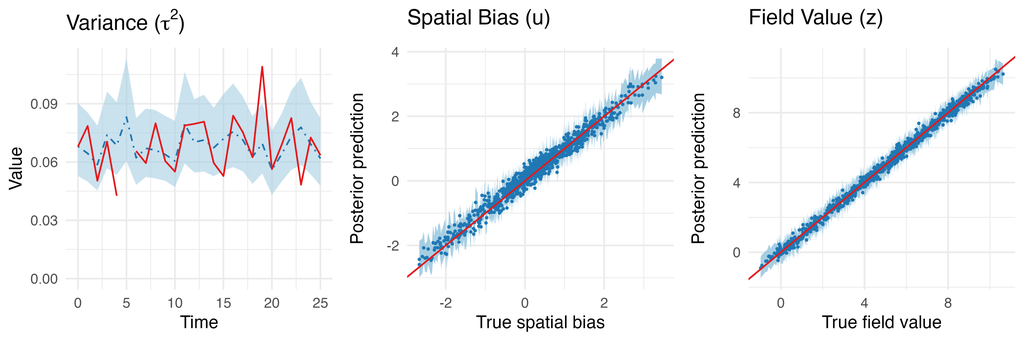

Original colours: light-blue ribbons (#A6CEE3), blue estimates (#1F78B4), and red truth or identity lines (#E31A1C). The field panel compares recovered replicated observations with the observed synthetic field.

```r
knitr::kable(r$scores, digits = 5,
  caption = "In-sample recovery summaries. interval_fraction is descriptive, not a calibrated coverage estimate.")
```

In-sample recovery summaries. interval_fraction is descriptive, not a calibrated coverage estimate.

| quantity | RMSE | interval_fraction | mean_interval_width |
| --- | --- | --- | --- |
| y | 0.04081 | 0.99786 | 0.49614 |
| u | 0.18944 | 0.96261 | 0.84769 |
| z_rep | 0.20389 | 0.99786 | 1.23412 |

The field and discrepancy comparisons use every observed site and time, with the spatial permutation explicitly aligned. Recovery conditions on the same field observations; it is not an out-of-sample prediction assessment. The replicated field adds fresh observation noise.

## Interpret the differences

The original full script moves a single Metropolis/Gibbs state through 30,000 emulator draws, without burn-in, starting at $(2.7,0.32,0,0.07,0)$. The package starts each fixed-emulator conditional Stan run at the midpoint of its parameter bounds: $(3,0.3,0,0.1,0)$, preserving the two fixed zero values. Its default zero-warmup transition uses stepsize 0.001. The original sampler estimates five parameters; this run estimates three. The initializations, transition kernels, and number of free parameters differ from the original inference script.

**One transition per emulator draw does not establish posterior convergence.** Narrow histograms can reflect initialization. No R-hat or effective-sample-size claim is made from these runs. A statistical reproduction of posterior parameter uncertainty requires warmup, many transitions per conditional, and diagnostics; the current run preserves the requested package default execution setup.

The current code also uses each emulator draw’s own variance and a kernel-consistent conditional variance. The development calibration helpers instead use a variance averaged across draws and a unit-amplitude conditional variance. These are additional reasons not to expect identical old histograms.

```r
knitr::kable(data.frame(
  conditional_runs = length(r$diagnostics),
  divergences = sum(vapply(r$diagnostics, `[[`, numeric(1), "divergences")),
  treedepth_hits = sum(vapply(r$diagnostics, `[[`, numeric(1), "max_treedepth_hits")),
  execution_only = r$execution_only
))
```

| conditional_runs | divergences | treedepth_hits | execution_only |
| --- | --- | --- | --- |
| 30000 | 0 | 0 | TRUE |

```r
if (all(is.finite(r$timing$seconds))) knitr::kable(r$timing, digits = 1)
```

| stage | seconds |
| --- | --- |
| emulation | 37.9 |
| calibration | 43066.6 |

The completed run has **0 divergences** and **0 maximum-treedepth hits**. The one-transition setup still requires longer, adapted runs when assessing posterior inference.

## Re-run and inspect saved objects

From the repository root:

```bash
R CMD INSTALL --library=spDBL/.r-library spDBL
Rscript vignettes/reproduce_spDBL/run_reproduction.R calibration full --dry-run
Rscript vignettes/reproduce_spDBL/run_reproduction.R calibration full
# Existing 300-draw quick report:
Rscript vignettes/reproduce_spDBL/run_reproduction.R calibration quick
```

The self-contained HTML is saved next to this source as `calibration-full.html` for the full profile or `calibration.html` for quick. `_results/calibration-full/` (full) and `_results/calibration/` (quick) contain the generated field, full serializable fit and recovery arrays, all conditional checkpoints, CSV summaries, figures, input checksums, and session information. After loading `calibration.rds`, longer conditional runs can reuse `fit$emulator`, `fit$field$z`, `fit$field$U`, and `fit$field$locations`; the emulator need not be fitted again.

These repository-specific reports live outside the spDBL package source and use external CSV data, so ordinary package builds do not include them.

[session information not shown]